# Week 7 | Simple Linear Regression

# Skills Quiz

## Question 2

Perform the following simple linear regression in R.

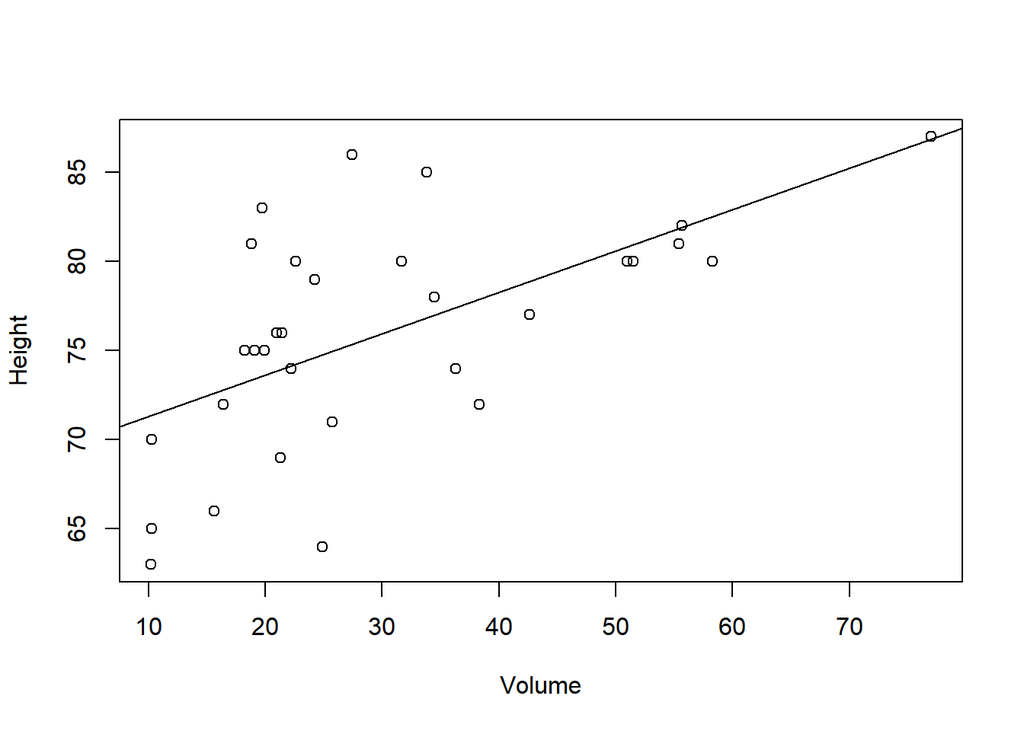

```r
plot(Height ~ Volume, data=trees)

trees.lm <- lm(Height ~ Volume, data=trees)

abline(trees.lm)
```

Check the assumptions of the linear regression using the following commands.

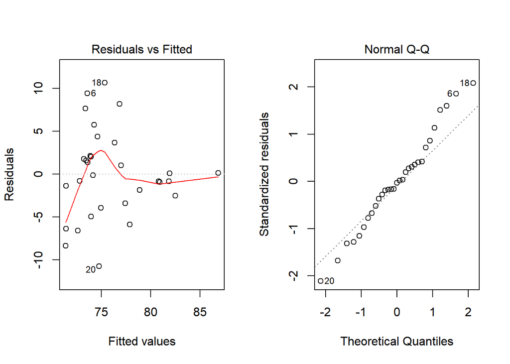

```r
par(mfrow=c(1,2))

plot(trees.lm, which=1:2)
```

```r
par(mfrow = c(1,1)) #This resets your plotting window for future plots.
```

## Question 3

Consider the Old Faithful Guyser (Yellowstone National Park) dataset in R.

```r
#?faithful
```

Perform a simple linear regression to determine if the expected waiting time to the next eruption can be modeled by the length of the previous eruption.

```r
faithful.lm <- lm(waiting ~ eruptions,
                  data = faithful)
summary(faithful.lm)
```

```
##
## Call:
## lm(formula = waiting ~ eruptions, data = faithful)
##
## Residuals:
##      Min       1Q   Median       3Q      Max
## -12.0796  -4.4831   0.2122   3.9246  15.9719
##
## Coefficients:
##             Estimate Std. Error t value Pr(>|t|)
## (Intercept)  33.4744     1.1549   28.98   <2e-16 ***
## eruptions    10.7296     0.3148   34.09   <2e-16 ***
## ---
## Signif. codes:  0 '***' 0.001 '**' 0.01 '*' 0.05 '.' 0.1 ' ' 1
##
## Residual standard error: 5.914 on 270 degrees of freedom
## Multiple R-squared:  0.8115, Adjusted R-squared:  0.8108
## F-statistic:  1162 on 1 and 270 DF,  p-value: < 2.2e-16
```

Answer: The estimated regression equation is given by

$\hat{Y}_i = 33.474 + 10.730 X_i$

Even though both the slope and intercept terms are  
significant, the intercept term is not of interest. This is because we are not interested in eruptions that last for zero minutes. However, the slope term is of interest. The slope tells us the increase in the expected waiting time to the next eruption for every 1 minute increase in the length of the current eruption. Specifically, for every one minute increase in the length of the current eruption, we would expect to wait 10.730 minutes longer (on average) until the next eruption.

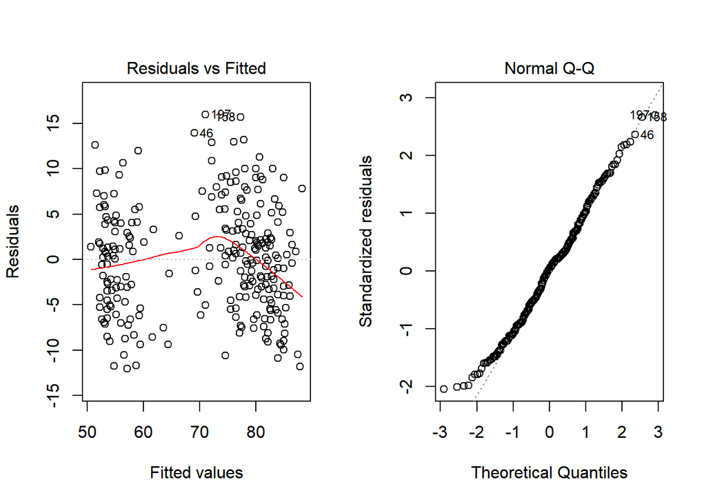

```r
par(mfrow=c(1,2))

plot(faithful.lm, which=1:2)
```

```r
par(mfrow = c(1,1)) #This resets your plotting window for future plots.
```

Produce a scatterplot in R of this linear regression.

Say the most recent eruption of the Old Faithful Guyser lasted for 3.5 minutes. Visitors should expect to wait _ minutes on average.

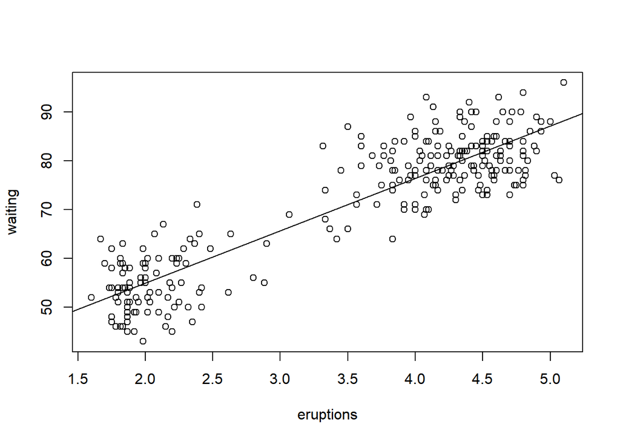

```r
plot(waiting ~ eruptions, data = faithful)

abline(faithful.lm)
```

By eyeballing it, we can see it’s about a 70 minute wait.